# Data Anlaysis for Hotel Booking

## Importing Nescesay Modules

```python
import numpy as np
import pandas as pd
import matplotlib.pyplot as plt
import seaborn as sns
```

```python
#Load the DataSET
```

```python
df=pd.read_csv('hotel_booking.csv')
df
```

|  | hotel | is_canceled | lead_time | arrival_date_year | arrival_date_month | arrival_date_week_number | arrival_date_day_of_month | stays_in_weekend_nights | stays_in_week_nights | adults | ... | customer_type | adr | required_car_parking_spaces | total_of_special_requests | reservation_status | reservation_status_date | name | email | phone-number | credit_card |
| --- | --- | --- | --- | --- | --- | --- | --- | --- | --- | --- | --- | --- | --- | --- | --- | --- | --- | --- | --- | --- | --- |
| 0 | Resort Hotel | 0 | 342 | 2015 | July | 27 | 1 | 0 | 0 | 2 | ... | Transient | 0.00 | 0 | 0 | Check-Out | 2015-07-01 | Ernest Barnes | Ernest.Barnes31@outlook.com | 669-792-1661 | ************4322 |
| 1 | Resort Hotel | 0 | 737 | 2015 | July | 27 | 1 | 0 | 0 | 2 | ... | Transient | 0.00 | 0 | 0 | Check-Out | 2015-07-01 | Andrea Baker | Andrea_Baker94@aol.com | 858-637-6955 | ************9157 |
| 2 | Resort Hotel | 0 | 7 | 2015 | July | 27 | 1 | 0 | 1 | 1 | ... | Transient | 75.00 | 0 | 0 | Check-Out | 2015-07-02 | Rebecca Parker | Rebecca_Parker@comcast.net | 652-885-2745 | ************3734 |
| 3 | Resort Hotel | 0 | 13 | 2015 | July | 27 | 1 | 0 | 1 | 1 | ... | Transient | 75.00 | 0 | 0 | Check-Out | 2015-07-02 | Laura Murray | Laura_M@gmail.com | 364-656-8427 | ************5677 |
| 4 | Resort Hotel | 0 | 14 | 2015 | July | 27 | 1 | 0 | 2 | 2 | ... | Transient | 98.00 | 0 | 1 | Check-Out | 2015-07-03 | Linda Hines | LHines@verizon.com | 713-226-5883 | ************5498 |
| ... | ... | ... | ... | ... | ... | ... | ... | ... | ... | ... | ... | ... | ... | ... | ... | ... | ... | ... | ... | ... | ... |
| 119385 | City Hotel | 0 | 23 | 2017 | August | 35 | 30 | 2 | 5 | 2 | ... | Transient | 96.14 | 0 | 0 | Check-Out | 2017-09-06 | Claudia Johnson | Claudia.J@yahoo.com | 403-092-5582 | ************8647 |
| 119386 | City Hotel | 0 | 102 | 2017 | August | 35 | 31 | 2 | 5 | 3 | ... | Transient | 225.43 | 0 | 2 | Check-Out | 2017-09-07 | Wesley Aguilar | WAguilar@xfinity.com | 238-763-0612 | ************4333 |
| 119387 | City Hotel | 0 | 34 | 2017 | August | 35 | 31 | 2 | 5 | 2 | ... | Transient | 157.71 | 0 | 4 | Check-Out | 2017-09-07 | Mary Morales | Mary_Morales@hotmail.com | 395-518-4100 | ************1821 |
| 119388 | City Hotel | 0 | 109 | 2017 | August | 35 | 31 | 2 | 5 | 2 | ... | Transient | 104.40 | 0 | 0 | Check-Out | 2017-09-07 | Caroline Conley MD | MD_Caroline@comcast.net | 531-528-1017 | ************7860 |
| 119389 | City Hotel | 0 | 205 | 2017 | August | 35 | 29 | 2 | 7 | 2 | ... | Transient | 151.20 | 0 | 2 | Check-Out | 2017-09-07 | Ariana Michael | Ariana_M@xfinity.com | 422-804-6403 | ************4482 |

119390 rows × 36 columns

```python
#Check Null Values
```

```python
#DATA CLEANING
```

```python
df.isnull()
```

|  | hotel | is_canceled | lead_time | arrival_date_year | arrival_date_month | arrival_date_week_number | arrival_date_day_of_month | stays_in_weekend_nights | stays_in_week_nights | adults | ... | customer_type | adr | required_car_parking_spaces | total_of_special_requests | reservation_status | reservation_status_date | name | email | phone-number | credit_card |
| --- | --- | --- | --- | --- | --- | --- | --- | --- | --- | --- | --- | --- | --- | --- | --- | --- | --- | --- | --- | --- | --- |
| 0 | False | False | False | False | False | False | False | False | False | False | ... | False | False | False | False | False | False | False | False | False | False |
| 1 | False | False | False | False | False | False | False | False | False | False | ... | False | False | False | False | False | False | False | False | False | False |
| 2 | False | False | False | False | False | False | False | False | False | False | ... | False | False | False | False | False | False | False | False | False | False |
| 3 | False | False | False | False | False | False | False | False | False | False | ... | False | False | False | False | False | False | False | False | False | False |
| 4 | False | False | False | False | False | False | False | False | False | False | ... | False | False | False | False | False | False | False | False | False | False |
| ... | ... | ... | ... | ... | ... | ... | ... | ... | ... | ... | ... | ... | ... | ... | ... | ... | ... | ... | ... | ... | ... |
| 119385 | False | False | False | False | False | False | False | False | False | False | ... | False | False | False | False | False | False | False | False | False | False |
| 119386 | False | False | False | False | False | False | False | False | False | False | ... | False | False | False | False | False | False | False | False | False | False |
| 119387 | False | False | False | False | False | False | False | False | False | False | ... | False | False | False | False | False | False | False | False | False | False |
| 119388 | False | False | False | False | False | False | False | False | False | False | ... | False | False | False | False | False | False | False | False | False | False |
| 119389 | False | False | False | False | False | False | False | False | False | False | ... | False | False | False | False | False | False | False | False | False | False |

119390 rows × 36 columns

```python
df.isnull().sum()
```

```
hotel                                  0
is_canceled                            0
lead_time                              0
arrival_date_year                      0
arrival_date_month                     0
arrival_date_week_number               0
arrival_date_day_of_month              0
stays_in_weekend_nights                0
stays_in_week_nights                   0
adults                                 0
children                               4
babies                                 0
meal                                   0
country                              488
market_segment                         0
distribution_channel                   0
is_repeated_guest                      0
previous_cancellations                 0
previous_bookings_not_canceled         0
reserved_room_type                     0
assigned_room_type                     0
booking_changes                        0
deposit_type                           0
agent                              16340
company                           112593
days_in_waiting_list                   0
customer_type                          0
adr                                    0
required_car_parking_spaces            0
total_of_special_requests              0
reservation_status                     0
reservation_status_date                0
name                                   0
email                                  0
phone-number                           0
credit_card                            0
dtype: int64
```

```python
# WE HAVE NULL VALUES AND WE NEED TO Remove them
# So first we need to find the datatype of each column in order to fill the null values
```

```python
df.info()
```

```
<class 'pandas.core.frame.DataFrame'>
RangeIndex: 119390 entries, 0 to 119389
Data columns (total 36 columns):
 #   Column                          Non-Null Count   Dtype
---  ------                          --------------   -----
 0   hotel                           119390 non-null  object
 1   is_canceled                     119390 non-null  int64
 2   lead_time                       119390 non-null  int64
 3   arrival_date_year               119390 non-null  int64
 4   arrival_date_month              119390 non-null  object
 5   arrival_date_week_number        119390 non-null  int64
 6   arrival_date_day_of_month       119390 non-null  int64
 7   stays_in_weekend_nights         119390 non-null  int64
 8   stays_in_week_nights            119390 non-null  int64
 9   adults                          119390 non-null  int64
```

[output cut: 28 more lines]

```python
#determine each column data type having a null value
```

```python
cnull = df.columns[df.isnull().any()]
for c in cnull:
    ncount = df[c].isnull().sum()
    print(f"Column: {c}, Null values: {ncount}")
```

```
Column: children, Null values: 4
Column: country, Null values: 488
Column: agent, Null values: 16340
Column: company, Null values: 112593
```

```python
df.info()
```

```
<class 'pandas.core.frame.DataFrame'>
RangeIndex: 119390 entries, 0 to 119389
Data columns (total 36 columns):
 #   Column                          Non-Null Count   Dtype
---  ------                          --------------   -----
 0   hotel                           119390 non-null  object
 1   is_canceled                     119390 non-null  int64
 2   lead_time                       119390 non-null  int64
 3   arrival_date_year               119390 non-null  int64
 4   arrival_date_month              119390 non-null  object
 5   arrival_date_week_number        119390 non-null  int64
 6   arrival_date_day_of_month       119390 non-null  int64
 7   stays_in_weekend_nights         119390 non-null  int64
 8   stays_in_week_nights            119390 non-null  int64
 9   adults                          119390 non-null  int64
```

[output cut: 28 more lines]

```python
df['children'].fillna(df['children'].mean(), inplace=True)
df.isnull().sum()
```

[output not shown]

```python
#Now we need to remove the nul values for object data type
```

```python
df = df.dropna(subset=['country'])
```

```python
df.isnull().sum()
```

```
hotel                                  0
is_canceled                            0
lead_time                              0
arrival_date_year                      0
arrival_date_month                     0
arrival_date_week_number               0
arrival_date_day_of_month              0
stays_in_weekend_nights                0
stays_in_week_nights                   0
adults                                 0
children                               0
babies                                 0
meal                                   0
country                                0
market_segment                         0
distribution_channel                   0
is_repeated_guest                      0
previous_cancellations                 0
previous_bookings_not_canceled         0
reserved_room_type                     0
assigned_room_type                     0
booking_changes                        0
deposit_type                           0
agent                              16006
company                           112279
days_in_waiting_list                   0
customer_type                          0
adr                                    0
required_car_parking_spaces            0
total_of_special_requests              0
reservation_status                     0
reservation_status_date                0
name                                   0
email                                  0
phone-number                           0
credit_card                            0
dtype: int64
```

```python
df['agent'].fillna(df['agent'].mean(), inplace=True)
df['company'].fillna(df['company'].mean(), inplace=True)
```

```python
df.isnull().sum()
```

```
hotel                             0
is_canceled                       0
lead_time                         0
arrival_date_year                 0
arrival_date_month                0
arrival_date_week_number          0
arrival_date_day_of_month         0
stays_in_weekend_nights           0
stays_in_week_nights              0
adults                            0
children                          0
babies                            0
meal                              0
country                           0
market_segment                    0
distribution_channel              0
is_repeated_guest                 0
previous_cancellations            0
previous_bookings_not_canceled    0
reserved_room_type                0
assigned_room_type                0
booking_changes                   0
deposit_type                      0
agent                             0
company                           0
days_in_waiting_list              0
customer_type                     0
adr                               0
required_car_parking_spaces       0
total_of_special_requests         0
reservation_status                0
reservation_status_date           0
name                              0
email                             0
phone-number                      0
credit_card                       0
dtype: int64
```

```python
# OUr dataset has no null , missing values
```

```python
cnull = df.columns[df.isnull().any()]
for c in cnull:
    ncount = df[c].isnull().sum()
    print(f"Column: {c}, Null values: {ncount}")
```

```python
#NO output meaning no null or missing or noisy data in our dataset
```

```python
 df['reservation_status_date'] = pd.to_datetime(df['reservation_status_date'])
```

```python
df.info()
```

```
<class 'pandas.core.frame.DataFrame'>
Index: 118902 entries, 0 to 119389
Data columns (total 36 columns):
 #   Column                          Non-Null Count   Dtype
---  ------                          --------------   -----
 0   hotel                           118902 non-null  object
 1   is_canceled                     118902 non-null  int64
 2   lead_time                       118902 non-null  int64
 3   arrival_date_year               118902 non-null  int64
 4   arrival_date_month              118902 non-null  object
 5   arrival_date_week_number        118902 non-null  int64
 6   arrival_date_day_of_month       118902 non-null  int64
 7   stays_in_weekend_nights         118902 non-null  int64
 8   stays_in_week_nights            118902 non-null  int64
 9   adults                          118902 non-null  int64
```

[output cut: 28 more lines]

```python
# to display the unique values for each categorical column in DataFrame.
#It can be useful for understanding the diversity and distribution of values within these columns,
#especially when dealing with categorical or textual data.
```

```python
for col in df.describe(include = 'object').columns:
    print(col)
    print(df[col].unique())
    print('-'*50)
```

```
hotel
['Resort Hotel' 'City Hotel']
--------------------------------------------------
arrival_date_month
['July' 'August' 'September' 'October' 'November' 'December' 'January'
 'February' 'March' 'April' 'May' 'June']
--------------------------------------------------
meal
['BB' 'FB' 'HB' 'SC' 'Undefined']
--------------------------------------------------
market_segment
['Direct' 'Corporate' 'Online TA' 'Offline TA/TO' 'Complementary' 'Groups'
 'Undefined' 'Aviation']
--------------------------------------------------
distribution_channel
['Direct' 'Corporate' 'TA/TO' 'Undefined' 'GDS']
--------------------------------------------------
reserved_room_type
['C' 'A' 'D' 'E' 'G' 'F' 'H' 'L' 'B' 'P']
--------------------------------------------------
assigned_room_type
['C' 'A' 'D' 'E' 'G' 'F' 'I' 'B' 'H' 'L' 'K' 'P']
--------------------------------------------------
deposit_type
['No Deposit' 'Refundable' 'Non Refund']
--------------------------------------------------
customer_type
['Transient' 'Contract' 'Transient-Party' 'Group']
--------------------------------------------------
reservation_status
['Check-Out' 'Canceled' 'No-Show']
--------------------------------------------------
name
['Ernest Barnes' 'Andrea Baker' 'Rebecca Parker' ... 'Wesley Aguilar'
 'Caroline Conley MD' 'Ariana Michael']
--------------------------------------------------
email
['Ernest.Barnes31@outlook.com' 'Andrea_Baker94@aol.com'
 'Rebecca_Parker@comcast.net' ... 'Mary_Morales@hotmail.com'
 'MD_Caroline@comcast.net' 'Ariana_M@xfinity.com']
--------------------------------------------------
phone-number
['669-792-1661' '858-637-6955' '652-885-2745' ... '395-518-4100'
 '531-528-1017' '422-804-6403']
--------------------------------------------------
credit_card
['************4322' '************9157' '************3734' ...
 '************9170' '************6349' '************7959']
--------------------------------------------------
```

```python
#Now let us summarize the dataset
```

```python
df.describe()
```

|  | is_canceled | lead_time | arrival_date_year | arrival_date_week_number | arrival_date_day_of_month | stays_in_weekend_nights | stays_in_week_nights | adults | children | babies | ... | previous_cancellations | previous_bookings_not_canceled | booking_changes | agent | company | days_in_waiting_list | adr | required_car_parking_spaces | total_of_special_requests | reservation_status_date |
| --- | --- | --- | --- | --- | --- | --- | --- | --- | --- | --- | --- | --- | --- | --- | --- | --- | --- | --- | --- | --- | --- |
| count | 118902.000000 | 118902.000000 | 118902.000000 | 118902.000000 | 118902.000000 | 118902.000000 | 118902.000000 | 118902.000000 | 118902.000000 | 118902.000000 | ... | 118902.000000 | 118902.000000 | 118902.000000 | 118902.000000 | 118902.000000 | 118902.000000 | 118902.000000 | 118902.000000 | 118902.000000 | 118902 |
| mean | 0.371373 | 104.308027 | 2016.157617 | 27.166726 | 15.800567 | 0.928891 | 2.502136 | 1.858404 | 0.104207 | 0.007948 | ... | 0.087139 | 0.131629 | 0.221174 | 86.544074 | 189.624792 | 2.330676 | 102.000808 | 0.061883 | 0.571706 | 2016-07-30 07:20:24.584952064 |
| min | 0.000000 | 0.000000 | 2015.000000 | 1.000000 | 1.000000 | 0.000000 | 0.000000 | 0.000000 | 0.000000 | 0.000000 | ... | 0.000000 | 0.000000 | 0.000000 | 1.000000 | 6.000000 | 0.000000 | -6.380000 | 0.000000 | 0.000000 | 2014-10-17 00:00:00 |
| 25% | 0.000000 | 18.000000 | 2016.000000 | 16.000000 | 8.000000 | 0.000000 | 1.000000 | 2.000000 | 0.000000 | 0.000000 | ... | 0.000000 | 0.000000 | 0.000000 | 9.000000 | 189.624792 | 0.000000 | 70.000000 | 0.000000 | 0.000000 | 2016-02-02 00:00:00 |
| 50% | 0.000000 | 69.000000 | 2016.000000 | 28.000000 | 16.000000 | 1.000000 | 2.000000 | 2.000000 | 0.000000 | 0.000000 | ... | 0.000000 | 0.000000 | 0.000000 | 28.000000 | 189.624792 | 0.000000 | 95.000000 | 0.000000 | 0.000000 | 2016-08-08 00:00:00 |
| 75% | 1.000000 | 161.000000 | 2017.000000 | 38.000000 | 23.000000 | 2.000000 | 3.000000 | 2.000000 | 0.000000 | 0.000000 | ... | 0.000000 | 0.000000 | 0.000000 | 152.000000 | 189.624792 | 0.000000 | 126.000000 | 0.000000 | 1.000000 | 2017-02-09 00:00:00 |
| max | 1.000000 | 737.000000 | 2017.000000 | 53.000000 | 31.000000 | 16.000000 | 41.000000 | 55.000000 | 10.000000 | 10.000000 | ... | 26.000000 | 72.000000 | 21.000000 | 535.000000 | 543.000000 | 391.000000 | 5400.000000 | 8.000000 | 5.000000 | 2017-09-14 00:00:00 |
| std | 0.483174 | 106.903127 | 0.707479 | 13.589774 | 8.780371 | 0.996211 | 1.900165 | 0.578576 | 0.399166 | 0.097379 | ... | 0.845855 | 1.484647 | 0.652775 | 102.992514 | 31.180604 | 17.630161 | 50.487004 | 0.244168 | 0.792678 | NaN |

8 rows × 21 columns

# 1. Cancellation Rate Visualization

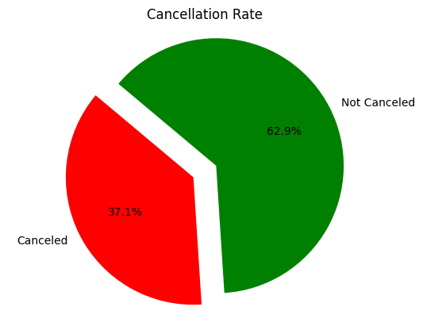

```python
cancelrate = df['is_canceled'].mean() * 100
labels = ['Canceled', 'Not Canceled']
sizes = [cancelrate, 100 - cancelrate]

# Step 3: Choose Colors and Explode
colors = ['red', 'green']
explode = (0.2, 0)  # Separation Between 2 slices (i.e., 'Canceled')

# Step 4: Plot the Pie Chart
plt.pie(sizes, explode=explode, labels=labels, colors=colors, autopct='%1.1f%%', startangle=140)
plt.axis('equal')

# Step 5: Display the Pie Chart
plt.title('Cancellation Rate')
plt.show()
```

```python
#explode parameter is used to emphasize a particular slice by "exploding" it away from the center of the pie chart
#It is a tuple of values where each value represents the fraction of the radius with which to offset each wedge
```

## 1.1 Indetail Check for City Hotel and Resort Hotel

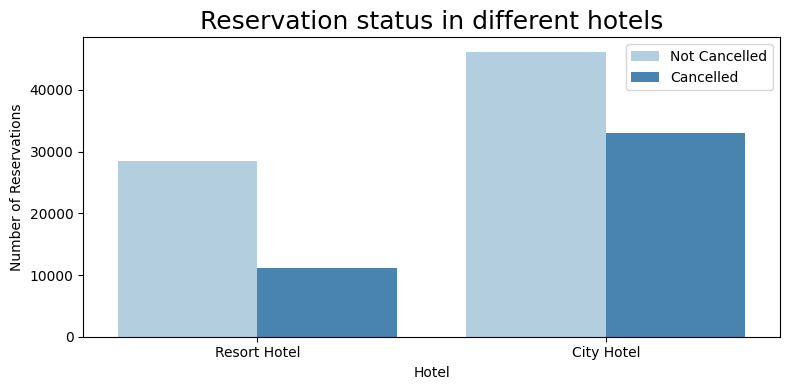

```python
plt.figure(figsize=(8,4))
ax1=sns.countplot(x='hotel',hue='is_canceled',data=df,palette='Blues')
legends_labels,_=ax1.get_legend_handles_labels()
ax1.legend(bbox_to_anchor=(1,1))
plt.title('Reservation status in different hotels', size=18)
plt.xlabel('Hotel')
plt.ylabel('Number of Reservations',)
plt.legend(['Not Cancelled','Cancelled'])
plt.tight_layout()
plt.show()
```

# 2.Booking patterns over Months

### Analyzing the temporal dynamics of hotel bookings provides invaluable insights into the ebb and flow of reservation patterns. Our investigation delves into monthly and annual trends, shedding light on when guests are most inclined to secure accommodations. From the seasonal peaks that mark heightened tourist activity to the nuanced variations in lead times, understanding these temporal patterns empowers hotel management to optimize strategies, allocate resources efficiently, and enhance the overall guest experience.

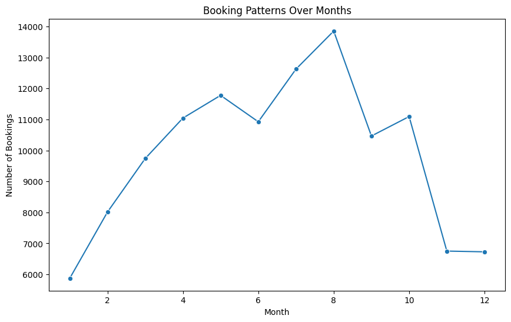

```python
df['arrival_month'] = pd.to_datetime(df['arrival_date_month'], format='%B').dt.month
monthlybook = df.groupby('arrival_month')['hotel'].count()
plt.figure(figsize=(10, 6))
sns.lineplot(x=monthly_bookings.index, y=monthlybook.values, marker='o')

# Set labels and title
plt.xlabel('Month')
plt.ylabel('Number of Bookings')
plt.title('Booking Patterns Over Months')

# Display the plot
plt.show()
```

# 3. Room Type Analysis Visualization

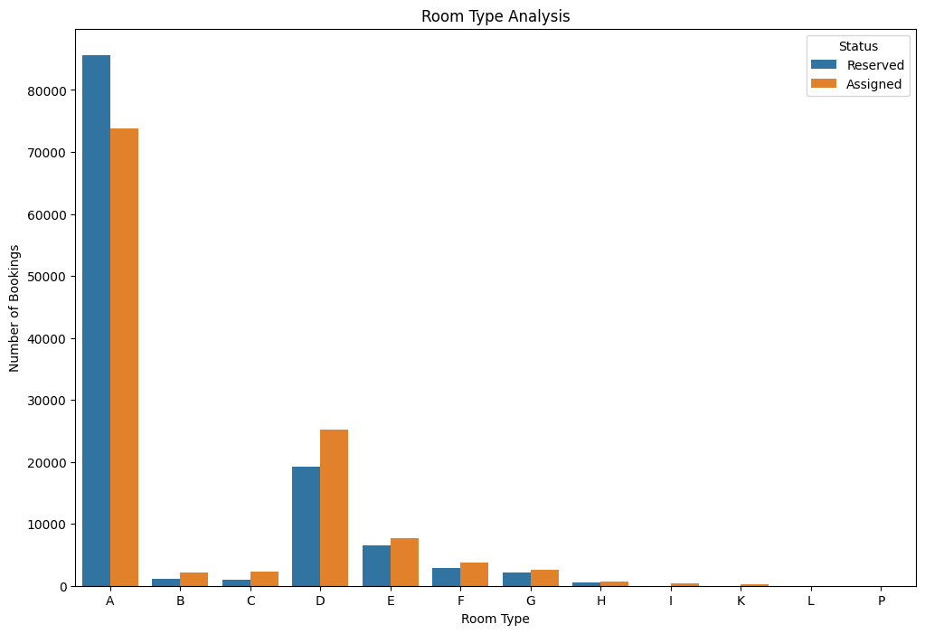

```python
reserved_counts = df['reserved_room_type'].value_counts()
assigned_counts = df['assigned_room_type'].value_counts()

# Create a DataFrame for plotting
room_type_df = pd.DataFrame({'Reserved': reserved_counts, 'Assigned': assigned_counts}).reset_index()

# Melt the DataFrame for better visualization
room_type_df_melted = pd.melt(room_type_df, id_vars='index', var_name='Status', value_name='Count')

# Plotting the grouped bar chart using seaborn
plt.figure(figsize=(12, 8))
sns.barplot(x='index', y='Count', hue='Status', data=room_type_df_melted)

# Set labels and title
plt.xlabel('Room Type')
plt.ylabel('Number of Bookings')
plt.title('Room Type Analysis')

# Display the plot
plt.show()
```

# 4.Meal Type Visualization

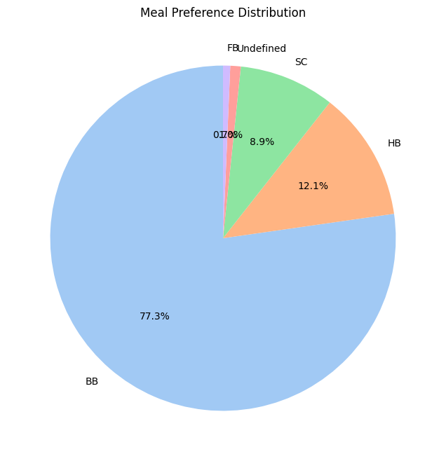

```python
meal_counts = df['meal'].value_counts()
plt.figure(figsize=(8, 8))
plt.pie(meal_counts, labels=meal_counts.index, autopct='%1.1f%%', startangle=90, colors=sns.color_palette("pastel"))
plt.title('Meal Preference Distribution')
plt.show()
```

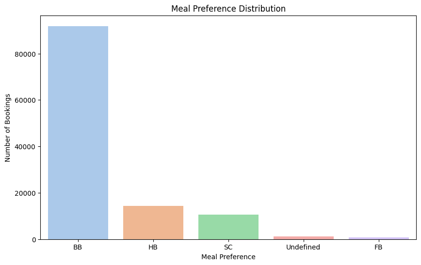

```python
plt.figure(figsize=(10, 6))
sns.barplot(x=meal_counts.index, y=meal_counts, palette="pastel")
plt.xlabel('Meal Preference')
plt.ylabel('Number of Bookings')
plt.title('Meal Preference Distribution')
plt.show()
```

# 5.Insights for Room Cancellation by Room Type

### Analysis of room cancellations by room type reveals varying cancellation rates across different room categories. Identifying room types with higher cancellations can guide strategies for optimization, while understanding the distribution of room type preferences informs operational decisions and marketing efforts to mitigate cancellations. These insights enable targeted approaches to enhance guest satisfaction and overall hotel performance.

# Step 1.Calculate Cancellation Rates by Room Type:

```python
room_cancellation = df.groupby('reserved_room_type')['is_canceled'].mean().sort_values()
print("Cancellation Rates by Room Type:")
print(room_cancellation)
```

```
Cancellation Rates by Room Type:
reserved_room_type
E    0.293828
F    0.304498
D    0.318208
B    0.329159
C    0.330827
L    0.333333
G    0.366299
A    0.392273
H    0.407654
P    1.000000
Name: is_canceled, dtype: float64
```

# Step 2.Visualize Cancellation Rates by Room Type:

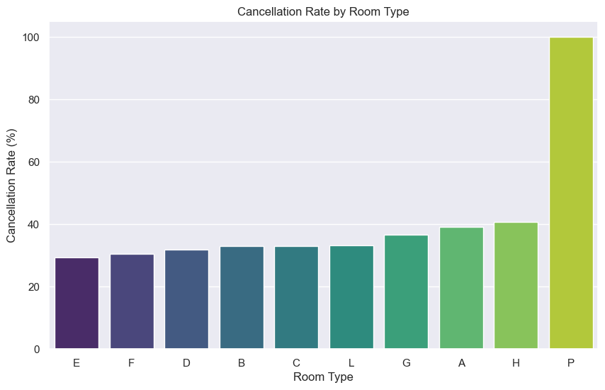

```python
sns.set(style="darkgrid")
plt.figure(figsize=(10, 6))
sns.barplot(x=room_cancellation.index, y=room_cancellation.values * 100, palette='viridis')
plt.title('Cancellation Rate by Room Type')
plt.xlabel('Room Type')
plt.ylabel('Cancellation Rate (%)')
plt.show()
```

# Step 3. Explore Room Type Preferences:

```python
# Count the occurrences of each reserved room type
room_type_counts = df['reserved_room_type'].value_counts()
print("Room Type Preferences:")
print(room_type_counts)
```

```
Room Type Preferences:
reserved_room_type
A    85601
D    19173
E     6497
F     2890
G     2083
B     1118
C      931
H      601
L        6
P        2
Name: count, dtype: int64
```

# Step 4. Visualize Room Type Preferences:

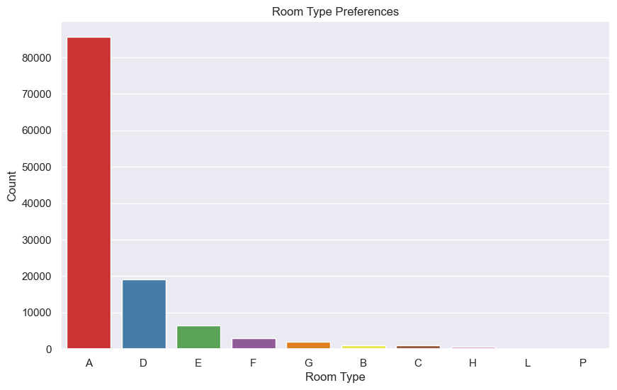

```python
# Create a bar chart for room type preferences
plt.figure(figsize=(10, 6))
sns.countplot(x='reserved_room_type', data=df, order=room_type_counts.index, palette='Set1')
plt.title('Room Type Preferences')
plt.xlabel('Room Type')
plt.ylabel('Count')
plt.show()
```

# 6. Insights of Booking Trends

### 6.1 Temporal Patterns: Booking distribution over months

### 6.2 Lead Time Analysis: Distribution of lead time

### 6.3 Booking Channel Trends: Distribution of booking channels

# 6.1 Temporal Patterns:

## Seasonal peaks in bookings suggest high demand during certain months, allowing hotels to optimize pricing and resource allocation for peak periods.

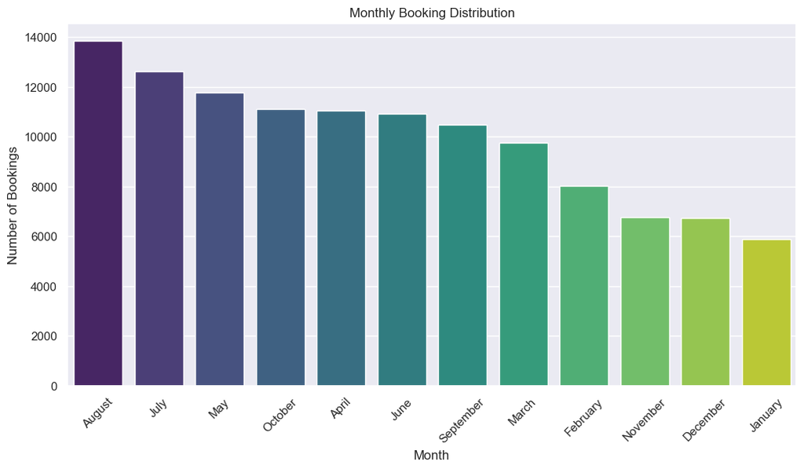

```python
# Temporal Patterns: Booking distribution over months
plt.figure(figsize=(12, 6))
sns.countplot(x='arrival_date_month', data=df, order=df['arrival_date_month'].value_counts().index, palette='viridis')
plt.title('Monthly Booking Distribution')
plt.xlabel('Month')
plt.ylabel('Number of Bookings')
plt.xticks(rotation=45)
plt.show()
```

# 6.2 Lead Time Analysis:

## Understanding lead time patterns helps in managing reservations effectively, adjusting staff levels, and tailoring marketing strategies for early or last-minute bookings

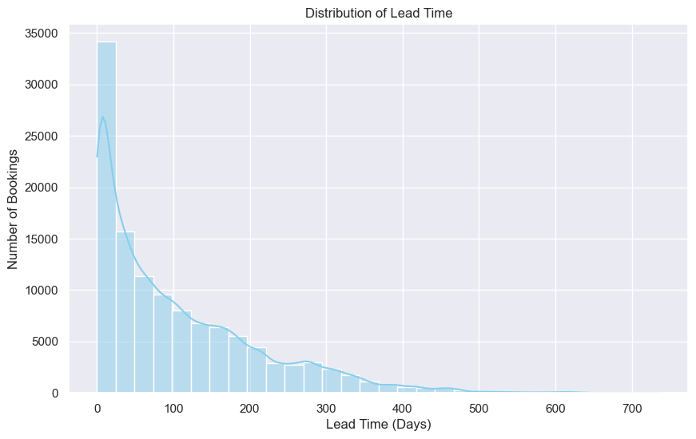

```python
# Lead Time Analysis: Distribution of lead time
plt.figure(figsize=(10, 6))
sns.histplot(df['lead_time'], bins=30, kde=True, color='skyblue')
plt.title('Distribution of Lead Time')
plt.xlabel('Lead Time (Days)')
plt.ylabel('Number of Bookings')
plt.show()
```

# 6.3 Booking Channel Trends:

## Identifying popular booking channels informs marketing focus, ensuring resources are allocated to the most effective channels for attracting guests.

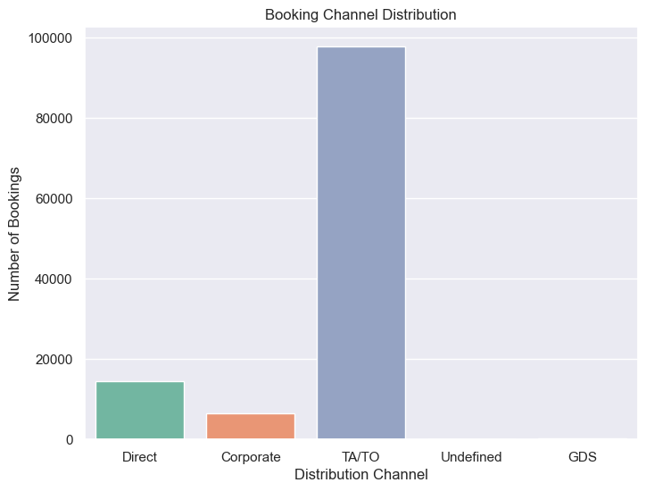

```python
# Booking Channel Trends: Distribution of booking channels
plt.figure(figsize=(8, 6))
sns.countplot(x='distribution_channel', data=df, palette='Set2')
plt.title('Booking Channel Distribution')
plt.xlabel('Distribution Channel')
plt.ylabel('Number of Bookings')
plt.show()
```

# 7.Customer Segmented Insights

## 7.1 Customer Segment Distribution

## 7.2 Booking Channel Preferences

## 7.3 Cancellation Rates by Segment

## 7.4 Lead Time Preferences

# 7.1 Customer Segment Distribution

### Insight: Visualizing the proportion of bookings from diverse customer segments.

### Use Case: Tailoring services and marketing strategies based on an understanding of the overall customer segment composition.

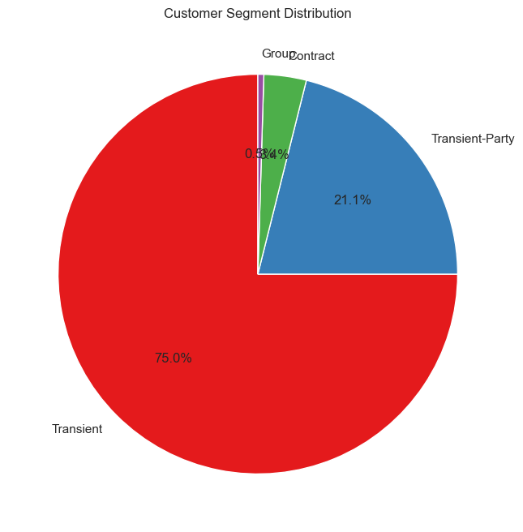

```python
# Customer Segment Distribution: Pie chart
plt.figure(figsize=(8, 8))
ctypecount = df['customer_type'].value_counts()
plt.pie(ctypecount, labels=customer_type_counts.index, autopct='%1.1f%%', colors=sns.color_palette('Set1'), startangle=90)
plt.title('Customer Segment Distribution')
plt.show()
```

## 7.2 Booking Channel Preferences

### Insight: Displaying booking channel preferences for each customer segment.

### Use Case: Informed marketing decisions, allowing targeted promotions aligned with the preferred booking channels of different customer segments.

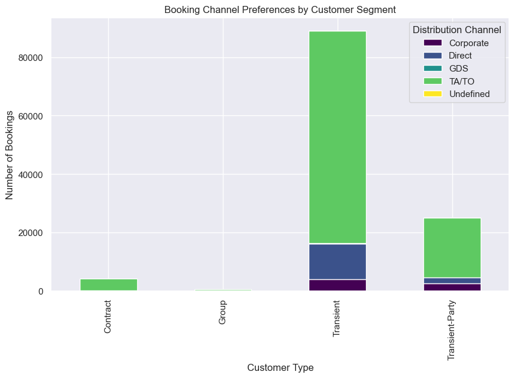

```python
# Booking Channel Preferences: Stacked bar chart
channel_segment_preferences = df.groupby(['customer_type', 'distribution_channel']).size().unstack()
channel_segment_preferences.plot(kind='bar', stacked=True, colormap='viridis', figsize=(10, 6))
plt.title('Booking Channel Preferences by Customer Segment')
plt.xlabel('Customer Type')
plt.ylabel('Number of Bookings')
plt.legend(title='Distribution Channel', loc='upper right')
plt.show()
```

## 7.3 Cancellation Rates by Segment

### Insight: Comparing cancellation rates across various customer segments.

### Use Case: Identifying segments with differing cancellation behaviors to implement tailored policies and improve overall booking reliability

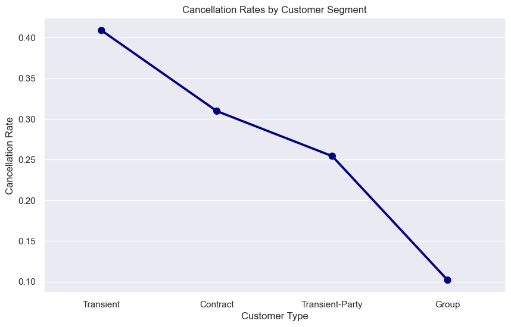

```python
# Cancellation Rates by Segment: Point plot
plt.figure(figsize=(10, 6))
sns.pointplot(x='customer_type', y='is_canceled', data=df, ci=None, color='navy')
plt.title('Cancellation Rates by Customer Segment')
plt.xlabel('Customer Type')
plt.ylabel('Cancellation Rate')
plt.show()
```

# 7.4 Lead Time Preferences

### Insight: Illustrating the distribution of lead times for bookings in distinct customer segments.

### Use Case: Informing strategies by understanding how different customer segments plan and book in advance or closer to their arrival dates.

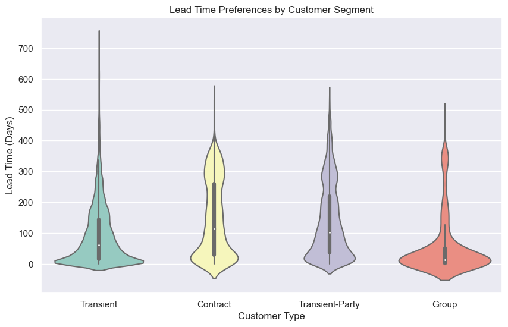

```python
# Lead Time Preferences: Violin plot
plt.figure(figsize=(10, 6))
sns.violinplot(x='customer_type', y='lead_time', data=df, palette='Set3')
plt.title('Lead Time Preferences by Customer Segment')
plt.xlabel('Customer Type')
plt.ylabel('Lead Time (Days)')
plt.show()
```